# Lecture 1 — BigQuery SQL Basics

Exploring the GA4 public ecommerce sample

Spencer Conway

I used the GA4 ecommerce sample to practice picking columns, filtering rows, and counting events in BigQuery. I kept the [GA4 export schema](https://support.google.com/analytics/answer/7029846#zippy=%2Cevent) handy to look up fields. The sample has fewer fields than the full export.

# 1. SELECT, FROM, and LIMIT

## 01. Preview event dates and names

```sql
SELECT event_date, event_name
FROM `bigquery-public-data.ga4_obfuscated_sample_ecommerce.events_*`
LIMIT 20;
```

I used `SELECT` to pick two columns and `LIMIT` to see just 20 rows. The order can change because I didn’t sort them.

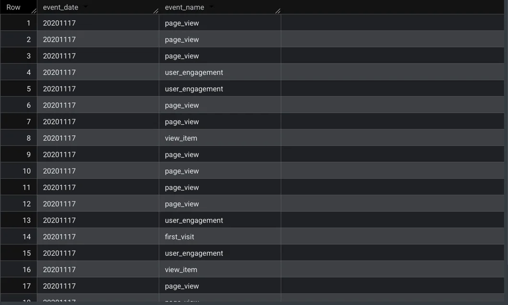

BigQuery results for Query 01

**Result.** The rows I can see are from November 17, 2020. I saw page views, item views, first visits, and user engagement.

# 2. Filter rows with WHERE

## 02. Preview purchase events

```sql
SELECT event_date, event_name, user_pseudo_id
FROM `bigquery-public-data.ga4_obfuscated_sample_ecommerce.events_*`
WHERE event_name = 'purchase'
LIMIT 50;
```

I added `WHERE` so I could see just the purchase rows and their user IDs.

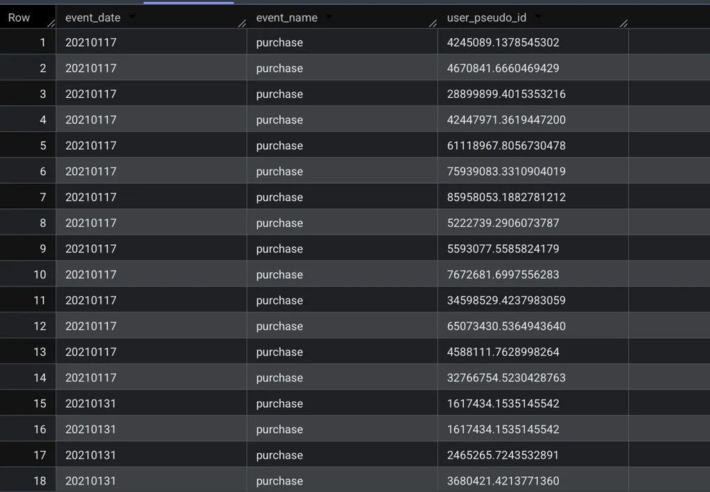

BigQuery results for Query 02

**Result.** Rows 15 and 16 have the same user ID. That helped me see how counting rows can give a different answer from counting users.

# 3. Sort results with ORDER BY

## 03. Find the most recent purchase events

```sql
SELECT event_date, event_timestamp, event_name
FROM `bigquery-public-data.ga4_obfuscated_sample_ecommerce.events_*`
WHERE event_name = 'purchase'
ORDER BY event_timestamp DESC
LIMIT 20;
```

I used `DESC` to put the newest purchases at the top. The time is still shown as a number in microseconds.

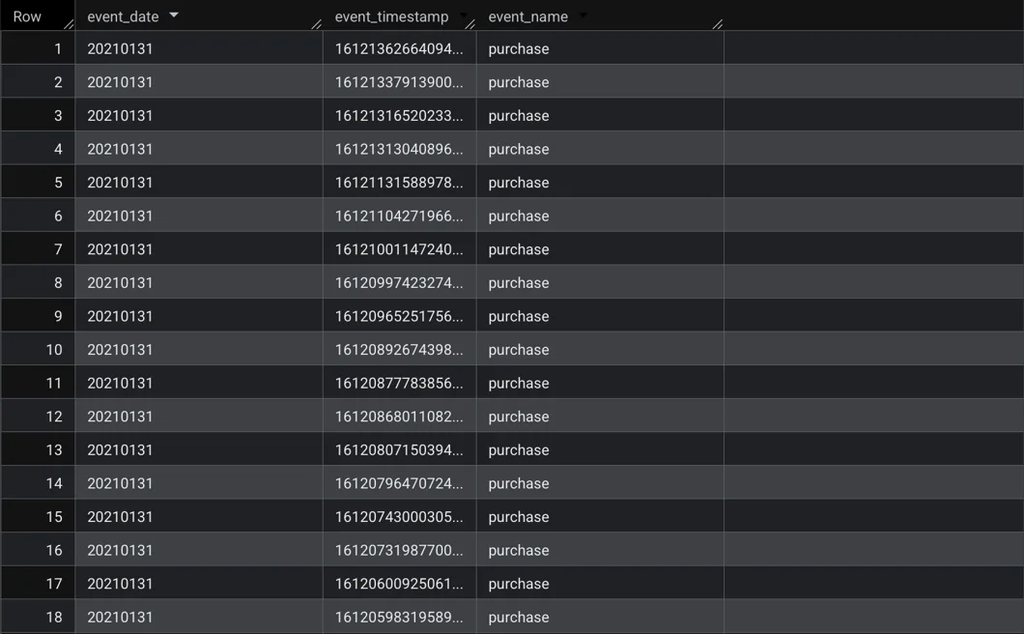

BigQuery results for Query 03

**Result.** All the purchases I can see are from January 31, 2021.

## 04. Read timestamps as dates and times

```sql
SELECT TIMESTAMP_MICROS(event_timestamp) AS event_time,
       event_name
FROM `bigquery-public-data.ga4_obfuscated_sample_ecommerce.events_*`
ORDER BY event_timestamp DESC
LIMIT 10;
```

I used `TIMESTAMP_MICROS` to turn that long number into a date and time I could read. I left out the purchase filter to see the latest events of any type.

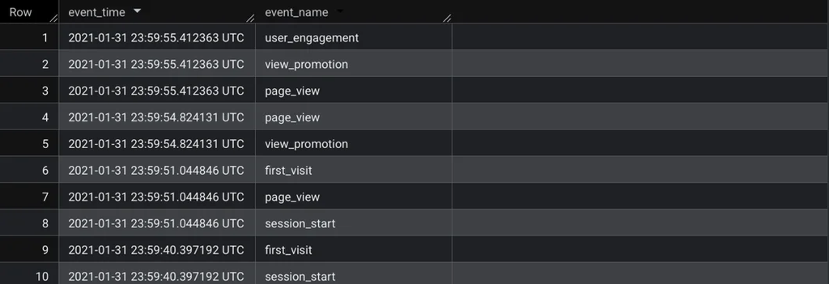

BigQuery results for Query 04

**Result.** The top three rows have the same time but different event names.

# 4. Summarize events with COUNT

## 05. Count all December events

```sql
SELECT COUNT(*) AS event_count
FROM `bigquery-public-data.ga4_obfuscated_sample_ecommerce.events_*`
WHERE _TABLE_SUFFIX BETWEEN '20201201' AND '20201231';
```

I used the table suffix to stick to December 2020, then counted all the rows with `COUNT(*)`.

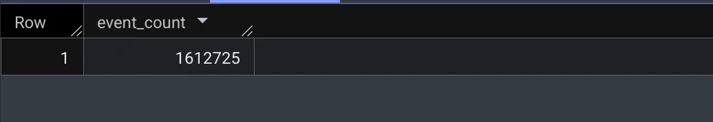

BigQuery results for Query 05

**Result.** I got 1,612,725 events for December.

## 06. Count December purchase events

```sql
SELECT COUNT(*) AS purchase_events
FROM `bigquery-public-data.ga4_obfuscated_sample_ecommerce.events_*`
WHERE event_name = 'purchase'
  AND _TABLE_SUFFIX BETWEEN '20201201' AND '20201231';
```

I kept the same dates and added the purchase filter. Each matching row counts as one purchase event.

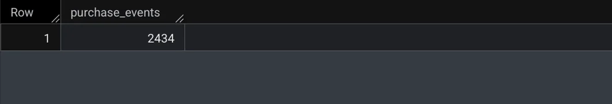

BigQuery results for Query 06

**Result.** I got 2,434 purchase events.

# 5. Choose the result grain with GROUP BY

## 07. Count events by day

```sql
SELECT event_date, COUNT(*) AS events
FROM `bigquery-public-data.ga4_obfuscated_sample_ecommerce.events_*`
WHERE _TABLE_SUFFIX BETWEEN '20201201' AND '20201231'
GROUP BY event_date
ORDER BY event_date;
```

I grouped by date so I could see a separate total for each day in December.

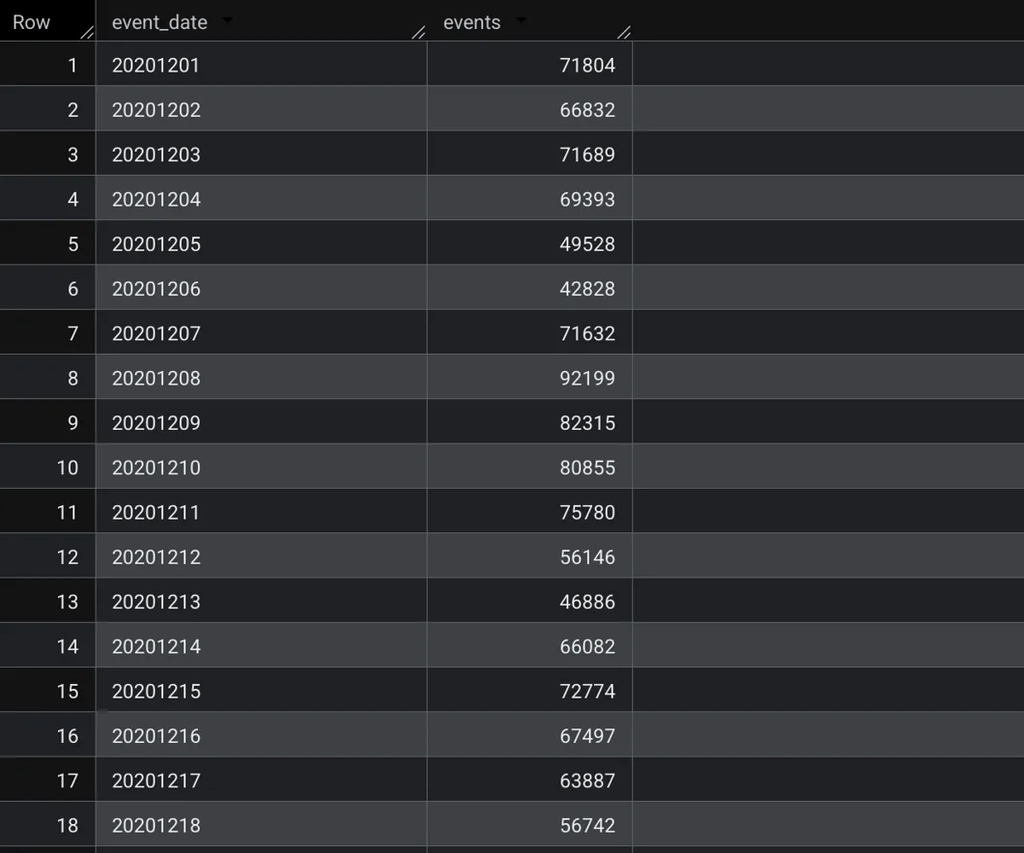

BigQuery results for Query 07

**Result.** Of the days I can see, December 8 had the most events at 92,199. The first seven days match Query 10.

## 08. Rank the most common event types

```sql
SELECT event_name, COUNT(*) AS events
FROM `bigquery-public-data.ga4_obfuscated_sample_ecommerce.events_*`
WHERE _TABLE_SUFFIX BETWEEN '20201201' AND '20201231'
GROUP BY event_name
ORDER BY events DESC
LIMIT 15;
```

I grouped by event name and sorted by the count to see the top 15 events in December.

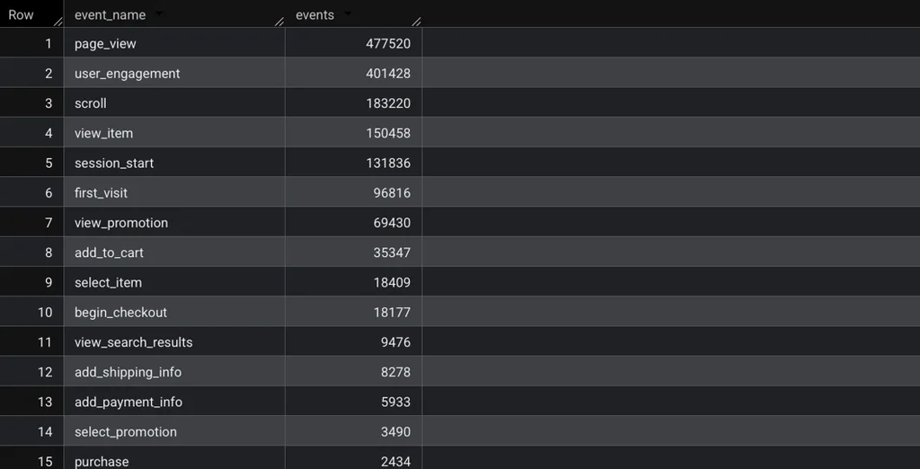

BigQuery results for Query 08

**Result.** Page views came first with 477,520. Purchase came in 15th with 2,434, the same number I got in Query 06.

# 6. Filter grouped results with HAVING

## 09. Keep event types with at least 50,000 events

```sql
SELECT event_name, COUNT(*) AS events
FROM `bigquery-public-data.ga4_obfuscated_sample_ecommerce.events_*`
WHERE _TABLE_SUFFIX BETWEEN '20201201' AND '20201231'
GROUP BY event_name
HAVING COUNT(*) >= 50000
ORDER BY events DESC;
```

I used `HAVING` to keep the groups that reached 50,000 events. The key difference for me was that the groups had to be counted first.

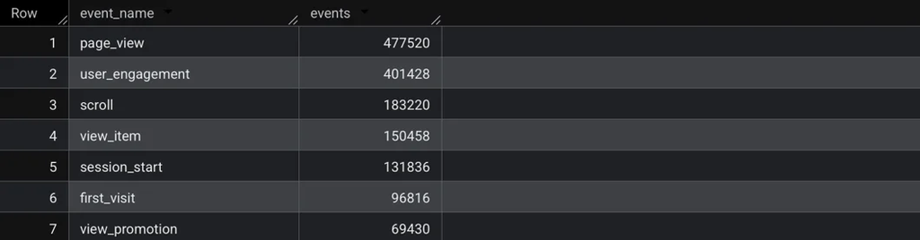

BigQuery results for Query 09

**Result.** Seven event types made the cut. `view_promotion` was the lowest one that qualified, with 69,430.

# 7. Select daily tables with a wildcard

## 10. Count events in the first week of December

```sql
SELECT event_date, COUNT(*) AS events
FROM `bigquery-public-data.ga4_obfuscated_sample_ecommerce.events_*`
WHERE _TABLE_SUFFIX BETWEEN '20201201' AND '20201207'
GROUP BY event_date
ORDER BY event_date;
```

I kept the same daily breakdown as Query 07 and changed the end date in `_TABLE_SUFFIX` to December 7.

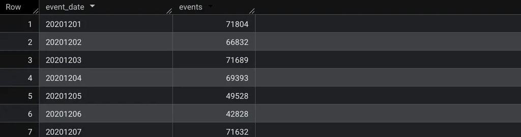

BigQuery results for Query 10

**Result.** December 1 was the busiest day that week with 71,804 events. December 6 was the lowest with 42,828.

# Publication links

- [GitHub repository](https://github.com/Spencerconway0/ibm-6500-sql-learning-portfolio)
- [GitHub Pages report](https://spencerconway0.github.io/ibm-6500-sql-learning-portfolio/lecture1-ga4.html)